# South Region - Richmond Times Dispatch

### TF IDF Table and Total Dataset Plots

Now, I start the process to create a TF-IDF table. I create a data_prep function, which will read in raw data and prep each set to become a TF-IDF table. Then, I combine all of the datasets together, and find the total word count and group them together.

I created an TF-IDF table from the left join of the word count and the total words. TF stands for Term Frequency, and IDF stands for Inverse Document Frequency. Term frequency is a metric to see how frequently a word shows up in the data when compared to the entire dataset. The inverse document frequency measures how much a word shows up in the article that it is originally from. The TF-IDF column is the values of the term frequency and the inverse document frequency multiplied together, and it represents the how crucial each word to its respective article in the scope of the entire dataset. I sorted My TF-IDF table in decreasing order so I could easily see which word was the most critical to my dataset. The word with the highest TF-IDF was migration, with a value of 0.06578. I believe this is because the article talks about the effect of people migration on climate change. Since the entire article has is concerned with migration, it makes sense that migration has the largest TF-IDF value.

```
## # A tibble: 2,984 x 7
##    names      word               n total     tf   idf tf_idf
##    <chr>      <chr>          <int> <int>  <dbl> <dbl>  <dbl>
##  1 Article 6  migration         11   850 0.0286  2.30 0.0658
##  2 Article 10 building          18  1234 0.0267  2.30 0.0615
##  3 Article 8  woolf             12  1046 0.0233  2.30 0.0537
##  4 Article 1  li                 8   760 0.02    2.30 0.0461
##  5 Article 9  transportation    12   897 0.0253  1.61 0.0407
##  6 Article 5  salas              7   759 0.0175  2.30 0.0404
##  7 Article 3  canada             7   835 0.0171  2.30 0.0394
##  8 Article 10 rice              15  1234 0.0223  1.61 0.0358
##  9 Article 10 campus            10  1234 0.0148  2.30 0.0342
## 10 Article 10 students          10  1234 0.0148  2.30 0.0342
## # ... with 2,974 more rows
```

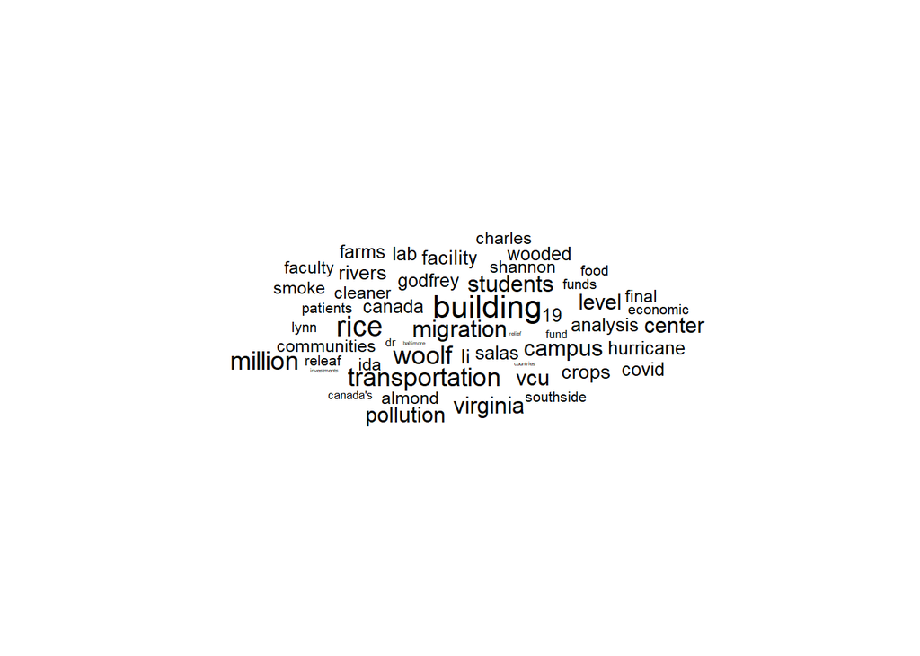

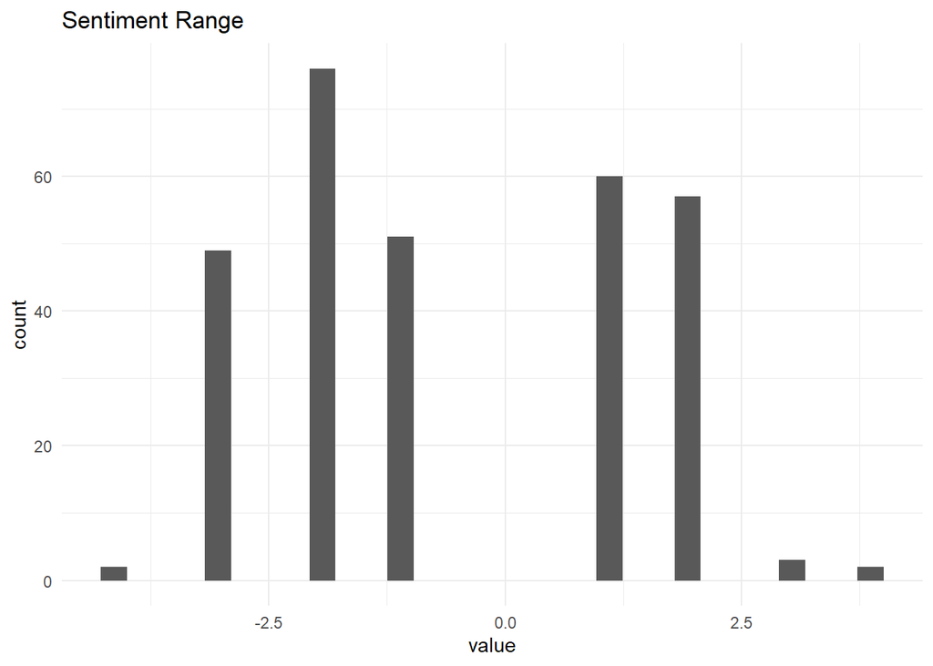

I created a table from the sentimental values returned by checking the words in my datasets with the nrc table. The table that was returned was interesting to see, as it slightly contradicted my histogram at first glance. The category with the most amount of words is the positive category, which doesn’t align with what the histogram represented. However, when looking at the other sentiments, there were 61 words under the disgust category, 150 under the fear category, 221 under the negative category, and 97 under the sadness category. This aligns more with with the histogram from earlier, as the histogram showed a larger degree of negatively charged words. This is also reflected in the table, as words that fall under disgust or anger are more likely to be negatively charged.

```
##
##        anger anticipation      disgust         fear          joy     negative
##           88          122           61          150           65          221
##     positive      sadness     surprise        trust
##          303           97           69          184
```